# Web Traffic Forecasting

## 1. Data Exploration

### 1.1 Import Libraries

```python
import numpy as np # linear algebra
import pandas as pd # data processing, CSV file I/O (e.g. pd.read_csv)

import os
import pandas as pd
import numpy as np
import matplotlib.pyplot as plt
import re

from sklearn.metrics import mean_squared_error
from math import sqrt

%matplotlib inline

print(os.listdir("./"))
```

```
['.ipynb_checkpoints', 'all', 'all.zip', 'Backups', 'WebTrafficExploration.ipynb']
```

### 1.2 Import Data

```python
#steps to create processed.csv from original data
#not required to run everytime
#read directly from processed.csv

#df = pd.read_csv('./all/train_1.csv').fillna(0)

#def breakdown_topic(name):
    #m = re.search('(.*)\_(.*)\.(.*).org\_(.*)\_(.*)', name)
    #return m

#for i in df.index:
    #print(i)
    #m = breakdown_topic(df.loc[i,'Page'])
    #df.loc[i,'PageName']= m[1]
    #df.loc[i,'Lang']= m[2]
    #df.loc[i,'Project']= m[3]
    #df.loc[i,'Access']= m[4]
    #df.loc[i,'Agent']= m[5]

#df.to_csv('./all/processed.csv')

#df.head(n=100)
```

Read data from processed.csv which was created from above train_1.csv using the code above. The above code is creating new features based off the first column "Page" which contains more details about the wiki page.

```python
df = pd.read_csv('./all/processed.csv').fillna(0)
print("Number of wiki pages is",df.shape[0]) #gives number of row count
print("Number of days is",df.shape[1]) #gives number of col count
```

```
Number of wiki pages is 145063
Number of days is 557
```

```python
#Lets look at the data in the csv file:
df.head()
```

|  | Unnamed: 0 | Page | 2015-07-01 | 2015-07-02 | 2015-07-03 | 2015-07-04 | 2015-07-05 | 2015-07-06 | 2015-07-07 | 2015-07-08 | ... | 2016-12-27 | 2016-12-28 | 2016-12-29 | 2016-12-30 | 2016-12-31 | PageName | Lang | Project | Access | Agent |
| --- | --- | --- | --- | --- | --- | --- | --- | --- | --- | --- | --- | --- | --- | --- | --- | --- | --- | --- | --- | --- | --- |
| 0 | 0 | 2NE1_zh.wikipedia.org_all-access_spider | 18.0 | 11.0 | 5.0 | 13.0 | 14.0 | 9.0 | 9.0 | 22.0 | ... | 20.0 | 22.0 | 19.0 | 18.0 | 20.0 | 2NE1 | zh | wikipedia | all-access | spider |
| 1 | 1 | 2PM_zh.wikipedia.org_all-access_spider | 11.0 | 14.0 | 15.0 | 18.0 | 11.0 | 13.0 | 22.0 | 11.0 | ... | 30.0 | 52.0 | 45.0 | 26.0 | 20.0 | 2PM | zh | wikipedia | all-access | spider |
| 2 | 2 | 3C_zh.wikipedia.org_all-access_spider | 1.0 | 0.0 | 1.0 | 1.0 | 0.0 | 4.0 | 0.0 | 3.0 | ... | 4.0 | 6.0 | 3.0 | 4.0 | 17.0 | 3C | zh | wikipedia | all-access | spider |
| 3 | 3 | 4minute_zh.wikipedia.org_all-access_spider | 35.0 | 13.0 | 10.0 | 94.0 | 4.0 | 26.0 | 14.0 | 9.0 | ... | 11.0 | 17.0 | 19.0 | 10.0 | 11.0 | 4minute | zh | wikipedia | all-access | spider |
| 4 | 4 | 52_Hz_I_Love_You_zh.wikipedia.org_all-access_s... | 0.0 | 0.0 | 0.0 | 0.0 | 0.0 | 0.0 | 0.0 | 0.0 | ... | 11.0 | 27.0 | 13.0 | 36.0 | 10.0 | 52_Hz_I_Love_You | zh | wikipedia | all-access | spider |

5 rows × 557 columns

- PageName: Page Name
- Lang: Page Language
- Project: Wikipedia project (e.g. wikipedia, wikimedia etc)
- Access: type of access (e.g. desktop)
- Agent: type of agent (e.g. spider).
- Page: contains all the information together. In other words, each article name has the following format: 'name_project_access_agent' (e.g. 'AKB48_zh.wikipedia.org_all-access_spider').

### 1.3 Data by category

Lets breakdown the data to look at it categorically. First we want to see the unique values for each categorical feature.

```python
df.Lang.unique()
```

```
array(['zh', 'fr', 'en', 'commons', 'ru', 'www', 'de', 'ja', 'es'],
      dtype=object)
```

```python
df.loc[df.Lang=="commons", 'Lang'] = "multi"
df.loc[df.Lang=="www", 'Lang'] = "multi"
df.Lang.unique()
```

```
array(['zh', 'fr', 'en', 'multi', 'ru', 'de', 'ja', 'es'], dtype=object)
```

The following are the values for other categories:

```python
df.Project.unique()
```

```
array(['wikipedia', 'wikimedia', 'mediawiki'], dtype=object)
```

```python
df.Access.unique()
```

```
array(['all-access', 'desktop', 'mobile-web'], dtype=object)
```

```python
df.Agent.unique()
```

```
array(['spider', 'all-agents'], dtype=object)
```

The following shows the number of data point by language, project, access and agent using visualization.

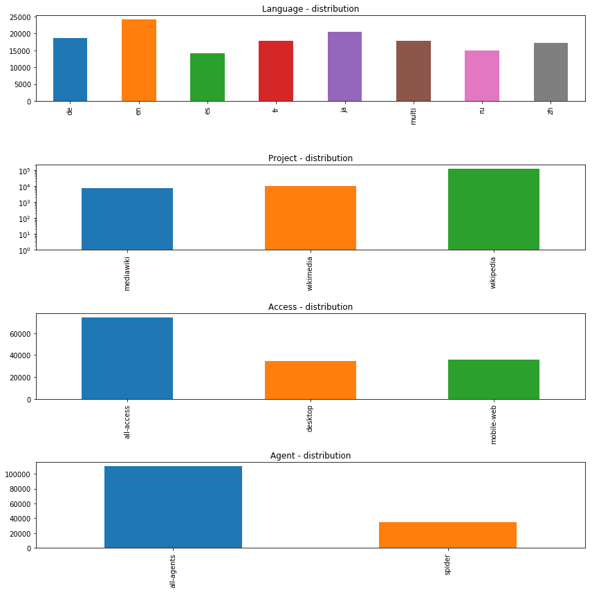

```python
fig, axs  = plt.subplots(4,1,figsize=(12,12))

df["Lang"].value_counts().sort_index().plot.bar(ax=axs[0])
axs[0].set_title('Language - distribution')

df["Project"].value_counts().sort_index().plot.bar(ax=axs[1],log = True)
axs[1].set_title('Project - distribution')

df["Access"].value_counts().sort_index().plot.bar(ax=axs[2])
axs[2].set_title('Access - distribution')

df["Agent"].value_counts().sort_index().plot.bar(ax=axs[3])
axs[3].set_title('Agent - distribution')


plt.tight_layout()
```

The above bar plot shows the break down of data based on different features. Note that this is based count of data points and not actual views. Some of the key points to note are:

### 1.4 Page views by time

Lets plot views for some of the wiki pages.

Some wiki pages in English are selected randomly and plotted to investigate into patterns and behvaiors.

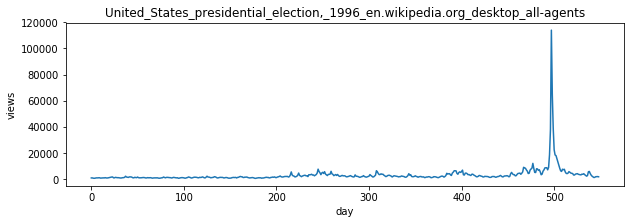

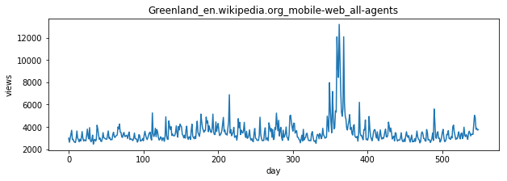

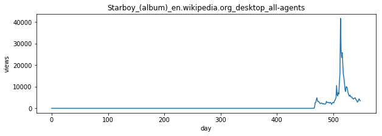

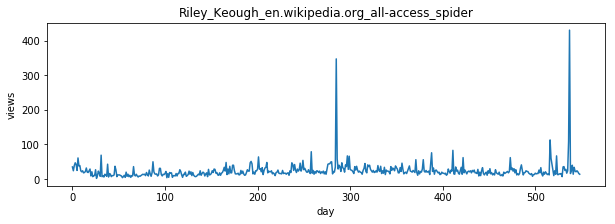

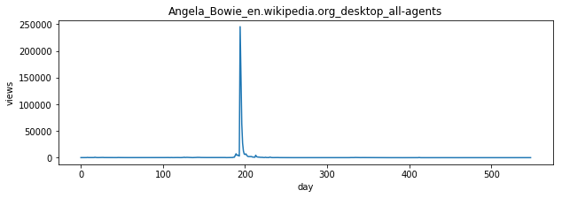

[figure not shown]

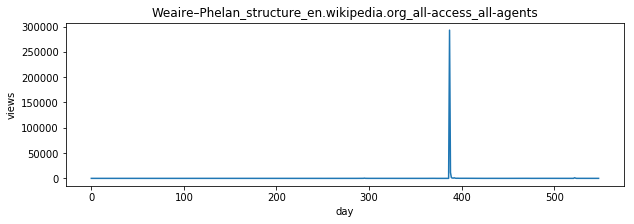

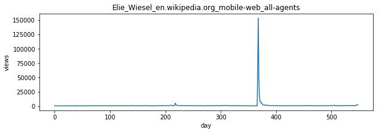

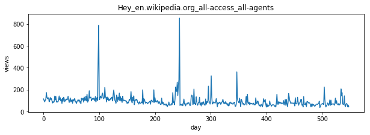

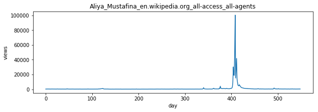

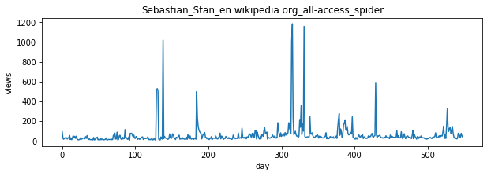

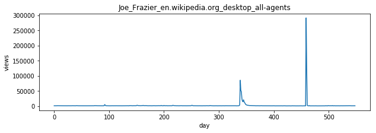

[8 more figures not shown]

```python
import random

df_en = df[df.Lang=="en"]
days = [r for r in range(df.iloc[:,2:-6].shape[1])]

def plot_entry(data,idx):
    fig = plt.figure(1,figsize=(10,3))
    plt.plot(days,data.iloc[idx,2:-6])
    plt.xlabel('day')
    plt.ylabel('views')
    plt.title(data.iloc[idx,1])
    plt.show()

random.seed(1)
for i in range(20):
    plot_entry(df_en, random.randint(1,len(df_en)))
```

The views on wiki pages seem very distinct without any distinguishing pattern. Some things to note are as follows:

- Most pages have *multiple spikes* in views indicating sudden interest due to current events.
- Some pages have *zero views in the beginning*, indicating that they might have been created within that range of dates (for e.g. Starboy).
- Max views for some pages is *>100,000* (e.g. US presidential election 1996) while others *<1000* (e.g. Riley Keough).
- There are some pages (e.g. Angela Bowie) which has >100,000 for one day while almost zero views for most other days.

The main takeaway from these plots is that the views on each page is different with unique pattern in spikes and a simple technique such as predicting the mean of views for the provided time period may not be a good strategy to forecast views.

## 2. Data Analysis

### 2.1 Average views per day (for every page)

Lets look at the average number of views for each language and its distribution:

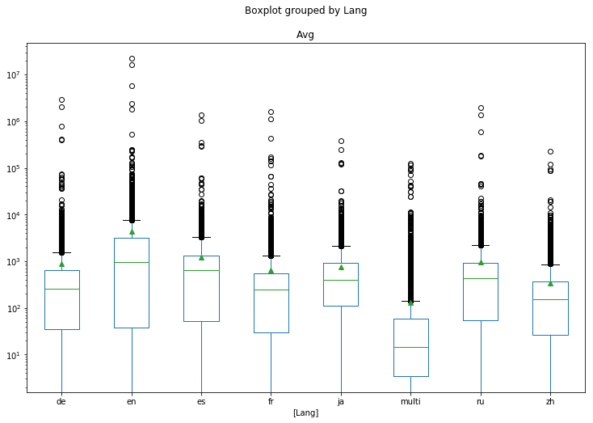

```python
#df[df['Lang']=="en"].iloc[idx,2:-6]
df['Avg'] = df.iloc[:,2:-6].mean(axis=1)
#df.head(n=5)

df.loc[:,['Avg','Lang']].boxplot(figsize=(12,8),showmeans=True,grid=False,by = 'Lang').set_yscale('log') #subplots by location
```

The following are some key observations from the boxplot:

- English wiki pages have the maximum avergae view (per day)
- Wiki pages with mutiple languages have the lowest average view
- There seem to be many outliers for each language, for forecasting it might be be prudent to pick web pages which have high average views to avoid pages which are not that popular.

### 2.2 Total number of views per day by Language

Lets explore the data further by summing up the number of views for each day for each language

```python
df_sample = df

df_views = df_sample.groupby(['Lang'], as_index=False).sum() #group each language, sum to find total views every day
df_views=df_views.set_index('Lang') #change index to Lang
df_views = df_views.drop('Unnamed: 0',axis = 1) #drop coulumns
df_views = df_views.drop('Avg',axis = 1)
df_views = df_views.T
df_views.head()
```

| Lang | de | en | es | fr | ja | multi | ru | zh |
| --- | --- | --- | --- | --- | --- | --- | --- | --- |
| 2015-07-01 | 13260519.0 | 84712190.0 | 15278553.0 | 8458638.0 | 11863200.0 | 1490534.0 | 9463854.0 | 4144988.0 |
| 2015-07-02 | 13079896.0 | 84438545.0 | 14601013.0 | 8512952.0 | 13620792.0 | 1561810.0 | 9627643.0 | 4151189.0 |
| 2015-07-03 | 12554042.0 | 80167728.0 | 13427632.0 | 8186030.0 | 12305383.0 | 1476261.0 | 8923463.0 | 4123659.0 |
| 2015-07-04 | 11520379.0 | 83463204.0 | 12606538.0 | 8749842.0 | 15456239.0 | 1260073.0 | 8393214.0 | 4163448.0 |
| 2015-07-05 | 13392347.0 | 86198637.0 | 13710356.0 | 8590493.0 | 14827204.0 | 1396521.0 | 8938528.0 | 4441286.0 |

Plot total views for each language over the time range. (note the log scale)

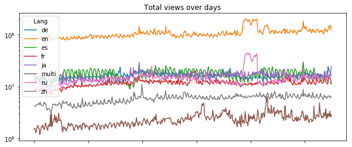

```python
df_views.plot(figsize=(10,4), title = "Total views over days", logy = True)
plt.show()
```

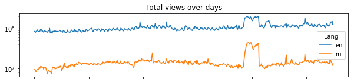

```python
df_views.loc[:,['en','ru']].plot(figsize=(10,2),title = "Total views over days", logy = True)
plt.show()
```

Indeed the correlation seems be to strong.

### 2.3 Components of time series data

There are two types of components in time series data: **systematic** and **non-systematic**.

Systematic data is consistent, recurrent and can be described and model while non-systematic data cannot be modeled directly.

The components of time series data are as follows:

1. **Level**: Average value in the series
2. **Trend**: Increasing and decreasing value in the series
3. **Seasonality**: repeating short-term cycle in the series
4. **Noise**: random variation in the series.

While level, trend and seasonality are the systematic components. Noise is a non-systematic component of time series data.

There are three types of models available to decompose time series data:

1. **Additive model:**

   ```
    y(t) = Level + Trend + Seasonality + Noise
   ```

2. **Multiplicative model:**

   ```
    y(t) = Level * Trend * Seasonality * Noise
   ```

3. **Pseudo-Additive model:**

   ```
    y(t) = Trend * (Seasonality + Noise - 1)
   ```

Here we use the "seasonal_decompose" function from the statsmodel library and the additive model to visualize total daily views of spanish and english wiki pages:

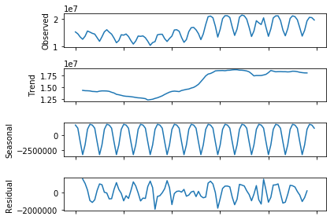

```python
import statsmodels.api as sm
plt.figure(figsize=(500, 500))
sm.tsa.seasonal_decompose(df_views.es[:100], freq=7).plot()
plt.show()
```

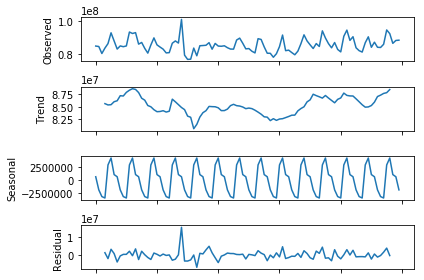

```python
import statsmodels.api as sm
plt.figure(figsize=(500, 500))
sm.tsa.seasonal_decompose(df_views.en[:100], freq=7).plot()
plt.show()
```

The above plot show that the seasonality of the data has a frequency of 7 days. Note that frequency is an input for the decompose function. A frequency of 7 was picked because it seem to provide the smoothest curve for the trend. This could be because of lower/higher views during weekend.

## 3. Data Transformation

### 3.1 Removing outliers

We need to remove outliers from the time series because they result in artifical trends in data which in our case is usually because of some current events causing huge number of people to view a wiki page. For example, while exploring the dataset I found a wiki aritcle that had <100 views on all days expect one when it had 100,000+ hits. On further investigation, I found that the wiki page was that of an obscure pop artist, who had been caught in a drug related police investigation on that day resulting in huge traffic to his wiki page. ITs unrealistic to expect the model to predict such anomalies as they may not repeat on a periodic basis. It is best to remove such data points in order to get more prediction for web traffic.

In order to determine the outliers, an upper and lower bound is defined and any value outside that band is considered an outlier. The bounds are a combination of mean absolute error and deviation of the data, both of which are calculated around the rolling mean with frequency 7 days. The outliers are replaced by the upper or lower bound.

### 3.2 Normalization

In order to have a consistent range of data and be able to compare results between different time series, each time series is normalized between 0 and 1. The formula for normalizing the _i_th element of a series is

\begin{equation*} x_i = \frac{x_{i}-x_{min}}{x_{max}-x_{min}} \end{equation*}

The following function called "RemoveOutliers" removes outliers as well as normalizes the data and returns a series with outlier removed.

```python
def RemoveOutliers(input, window, plot_intervals=False, scale=1, plot_anomalies=False):

    """
        series - dataframe with timeseries
        window - rolling window size
        plot_intervals - show confidence intervals
        plot_anomalies - show anomalies

    """
    series = input.copy()
    rolling_mean = series.rolling(window=window).mean()
    #print(rolling_mean)
    plt.figure(figsize=(15,5))
    plt.title("Moving average\n window size = {}".format(window))
    plt.plot(rolling_mean, "g", label="Rolling mean trend")

    # Plot confidence intervals for smoothed values
    if plot_intervals:
        mae = mean_absolute_error(series[window:], rolling_mean[window:])
        deviation = np.std(series[window:] - rolling_mean[window:])
        lower_bond = rolling_mean - (mae + scale * deviation)
        upper_bond = rolling_mean + (mae + scale * deviation)
        plt.plot(upper_bond, "r--", label="Upper Bound")
        plt.plot(lower_bond, "r--", label="Lower Bound")

        # Having the intervals, find abnormal values
        if plot_anomalies:
            #series[(series<lower_bond)|(series>upper_bond)] = upper_bond
            anomalies = []
            anomalies = series[(series<lower_bond)|(series>upper_bond)]
            series[series<lower_bond] = lower_bond
            series[series>upper_bond] = upper_bond
            #anomalies = pd.DataFrame(index=series.index)
            #anomalies[series<lower_bond] = series[series<lower_bond]
            #anomalies[series<lower_bond] = series.loc[series<lower_bond]
            #anomalies[series>upper_bond] = series[series>upper_bond]
            #print(anomalies)
            plt.plot(anomalies, "ro", markersize=10, label="Anomalies")

    plt.plot(series[window:], label="Actual values")
    plt.legend(loc="upper left")
    plt.grid(True)

    series=(series-series.min())/(series.max()-series.min()) #normalize data b/w 0 and 1
    series[series==0]=10**-6  #replace zero by by a non-zero low value
    return series
```

The following example shows data with outliers removed for total daily views of russian wiki pages. The red dots are the outliers, the green line is the rolling mean average, the broken lines are upper and lower bounds while the blue line is the data with outliers removed.

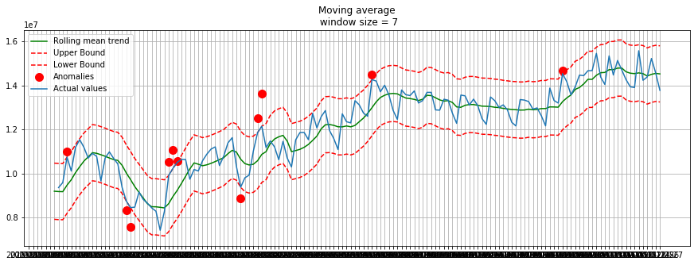

```python
dfn_ru = RemoveOutliers(df_views['ru'][:150], 7, plot_intervals=True, plot_anomalies=True)
```

## 4. Forecasting

### 4.1 Holt-Winter's Method (Triple exponential smoothing)

Exponential Smoothing methods predict future values based on the weighted average of current value and previous values. The **triple** exponential method takes into account the level, trend and seasonality of previous and current values to predict future points.

More detailed explanation of triple exponential smoothing with equations can be found here: https://www.itl.nist.gov/div898/handbook/pmc/section4/pmc435.htm

*Holt_Prediction_function* outputs the predictions using four methods:

```
    - additive seasonal
    - multiplicative seasonal
    - additive seasonal damped
    - multiplicative seasonal damped
```

A fifth method is used to benchmark our model. This benchmark is a **"simple model"** which predicts that the observation in the next n days will be the same as last n days.

```python
from statsmodels.tsa.holtwinters import ExponentialSmoothing

#Source: https://www.statsmodels.org/dev/examples/notebooks/generated/exponential_smoothing.html

def HoltWinters_Prediction_function(data):

    data.index = pd.to_datetime(data.index)
    data = data.asfreq('d')

    train, test = data.iloc[:100], data.iloc[100:]

    fit1 = ExponentialSmoothing(train, seasonal_periods=7, trend='add', seasonal='add').fit(use_boxcox=False)
    fit2 = ExponentialSmoothing(train, seasonal_periods=7, trend='add', seasonal='mul').fit(use_boxcox=False)
    fit3 = ExponentialSmoothing(train, seasonal_periods=7, trend='add', seasonal='add', damped=True).fit(use_boxcox=False)
    fit4 = ExponentialSmoothing(train, seasonal_periods=7, trend='add', seasonal='mul', damped=True).fit(use_boxcox=False)

    results=pd.DataFrame(index=[r"$\alpha$",r"$\beta$",r"$\phi$",r"$\gamma$",r"$l_0$","$b_0$","SSE"])

    params = ['smoothing_level', 'smoothing_slope', 'damping_slope', 'smoothing_seasonal', 'initial_level', 'initial_slope']

    results["Additive"]       = [fit1.params[p] for p in params] + [fit1.sse]
    results["Multiplicative"] = [fit2.params[p] for p in params] + [fit2.sse]
    results["Additive Dam"]   = [fit3.params[p] for p in params] + [fit3.sse]
    results["Multiplica Dam"] = [fit4.params[p] for p in params] + [fit4.sse]

    ax = data.plot(figsize=(10,6), color='black', title="Forecasts from Holt-Winters' multiplicative method" )
    ax.set_ylabel("Views")
    ax.set_xlabel("Days")
    #fit1.fittedvalues.plot(ax=ax, style='--', color='red')
    #fit2.fittedvalues.plot(ax=ax, style='--', color='green')
    #fit3.fittedvalues.plot(ax=ax, style='--', color='blue')
    #fit4.fittedvalues.plot(ax=ax, style='--', color='black')


    pred1 = fit1.predict(start=test.index[0], end=test.index[-1])
    pred2 = fit2.predict(start=test.index[0], end=test.index[-1])
    pred3 = fit3.predict(start=test.index[0], end=test.index[-1])
    pred4 = fit4.predict(start=test.index[0], end=test.index[-1])
    pred5 =  train.iloc[50:100]
    pred5.index = test.index

    pred1.rename('Holt-Winters (add-add-seasonal)').plot(ax=ax, style='--',  color='red', legend=True)
    pred2.rename('Holt-Winters (add-mul-seasonal)').plot(ax=ax, style='--', color='green', legend=True)
    pred3.rename('Holt-Winters (add-add-seasonal) - damped').plot(ax=ax, style='--',  color='blue', legend=True)
    pred4.rename('Holt-Winters (add-mul-seasonal) - damped').plot(ax=ax, style='--',  color='pink', legend=True)
    pred5.rename('Simple Model)').plot(ax=ax, style='--',  color='cyan', legend=True)

    plt.show()
    print("Forecasting views of wiki pages using Holt-Winters method with both additive and multiplicative seasonality.")

    results

    HoltWinters_Prediction = pd.concat([pred1, pred2, pred3, pred4,pred5], axis=1)
    #HoltWinters_Prediction.columns[4] = "5"
    #pd.DataFrame({'pred1': pred1, 'pred2': pred2, 'pred3': pred3, 'pred4': pred4})
    #for i in range(7):
    #   HoltWinters_r2score = HoltWinters_r2score.append({'add-seas': (r2_score(actual[i*7:(i+1)*7], prediction1[i*7:(i+1)*7])), 'mul-seas': (r2_score(actual[i*7:(i+1)*7], prediction2[i*7:(i+1)*7])), 'add-seas-dam': (r2_score(actual[i*7:(i+1)*7], prediction3[i*7:(i+1)*7])), 'mul-seas-dam': (r2_score(actual[i*7:(i+1)*7], prediction4[i*7:(i+1)*7]))}, ignore_index=True)

    return HoltWinters_Prediction
```

### 4.2 Evaluation metrics: Root Mean Square Error (RMSE)

Root Mean Square Error (RMSE) is used for evaluating the predictions made by the model. The mean squared error (MSE) is the average of the squared prediction errors. Squaring the error values gives a positive number and also puts more weight on large errors. RMSE is the root of MSE which has the same unit as the observations.

We create a function called *HoltWinters_RMSE_Plot* that takes the predicted values and plots the RMSE for predictions for every week. It also return a table with weekly errors from each of the 5 methods described in section 4.1

```python
def HoltWinters_RMSE_Plot(actual,prediction_df,language):

    prediction1 = prediction_df[0]
    prediction2 = prediction_df[1]
    prediction3 = prediction_df[2]
    prediction4 = prediction_df[3]
    prediction5 = prediction_df.iloc[:,4]

    HoltWinters_RMSE = pd.DataFrame({'add-seas': [], 'mul-seas': [], 'add-seas-dam': [], 'mul-seas-dam': [], 'simple-model': []})
    for i in range(7):
        HoltWinters_RMSE = HoltWinters_RMSE.append({'add-seas': sqrt(mean_squared_error(actual[i*7:(i+1)*7], prediction1[i*7:(i+1)*7])), 'mul-seas': sqrt(mean_squared_error(actual[i*7:(i+1)*7], prediction2[i*7:(i+1)*7])), 'add-seas-dam': sqrt(mean_squared_error(actual[i*7:(i+1)*7], prediction3[i*7:(i+1)*7])), 'mul-seas-dam': sqrt(mean_squared_error(actual[i*7:(i+1)*7], prediction4[i*7:(i+1)*7])), 'simple-model': sqrt(mean_squared_error(actual[i*7:(i+1)*7], prediction5[i*7:(i+1)*7]))}, ignore_index=True)

    labels = ['add-seasonal', 'mul-seasonal', 'add-seas-damped', 'mul-seas-damped','simple-model']
    colors=['r','g','b','m','c']

    for i in range(0,5):
        plt.plot(HoltWinters_RMSE.iloc[:,i],'o-',color=colors[i],label=labels[i])

    plt.xlabel('week')
    plt.ylabel('RMSE')
    plt.title('RMSE for total daily views of '+language+ ' wiki pages \n using Holt-Winters exponential Smoothing\n')
    plt.legend()
    plt.show()

    return HoltWinters_RMSE
```

### 4.3.1. Predictions for total daily views (by language)

Lets start making predictions for total daily views for english, spanish and Japanese wiki pages.

#### 4.3.1.a. English

The following plot shows the outliers and the daily views for all english wiki pages after removing the outliers.

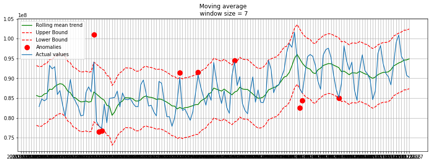

```python
dfn_en = RemoveOutliers(df_views['en'][:150], 7, plot_intervals=True, plot_anomalies=True)
```

The next graph shows the prediction of daily views for English wiki pages. The solid black line shows the observed values while broken line shows the predictions using different options in Holt-Winters method. Each rise and drop is about a week.

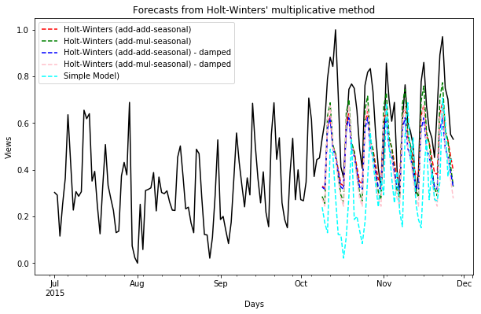

```
Forecasting views of wiki pages using Holt-Winters method with both additive and multiplicative seasonality.
```

```python
HoltWinters_Prediction_en = HoltWinters_Prediction_function(dfn_en)
```

The figure shows that the predictions are poor in the beginning as the model is not able to predict the sudden jump in traffic in the second week of October. However, the prediction seem to improve as the traffic becomes slightly stable.

Here we calculate the RMSE of the predictions on a weekly basis and plot it.

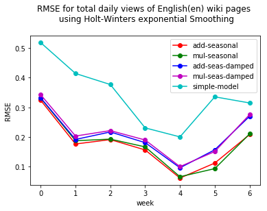

```python
#HoltWinters_r2score_en = HoltWinters_R2Score_Plot(df_views['en'][100:150],HoltWinters_Prediction_en,"English(en)")
HoltWinters_RMSE_en = HoltWinters_RMSE_Plot(dfn_en[100:150],HoltWinters_Prediction_en,"English(en)")
```

```python
HoltWinters_RMSE_en
```

|  | add-seas | mul-seas | add-seas-dam | mul-seas-dam | simple-model |
| --- | --- | --- | --- | --- | --- |
| 0 | 0.323749 | 0.331487 | 0.331881 | 0.342532 | 0.518272 |
| 1 | 0.176430 | 0.187444 | 0.191764 | 0.203248 | 0.414300 |
| 2 | 0.191319 | 0.192948 | 0.217022 | 0.221592 | 0.376986 |
| 3 | 0.156394 | 0.166654 | 0.181032 | 0.189892 | 0.230803 |
| 4 | 0.061557 | 0.066081 | 0.096166 | 0.100130 | 0.200401 |
| 5 | 0.112166 | 0.093425 | 0.156918 | 0.151089 | 0.335551 |
| 6 | 0.208327 | 0.210419 | 0.269956 | 0.275645 | 0.314869 |

```python
HoltWinters_RMSE_en.mean()
```

```
add-seas        0.175706
mul-seas        0.178351
add-seas-dam    0.206391
mul-seas-dam    0.212018
simple-model    0.341597
dtype: float64
```

A few observations from the above plots and graphs:

- The error from the "simple model" (which predicts that next n values will be same as the last n values) is much higher than the Holt-Winter techniques.
- There is significant improvement in RMSE week 2 onwards with RMSE dropping from ~0.3 to ~0.2 in second week and upto ~0.06 by fourth week
- If we look at the average RMSE from different techniques, additive seasonal and multiplicative season give the lowest errors.

Now we will repeat this exercise with Spanish and Japanese wiki pages.

#### 4.3.1.b Spanish

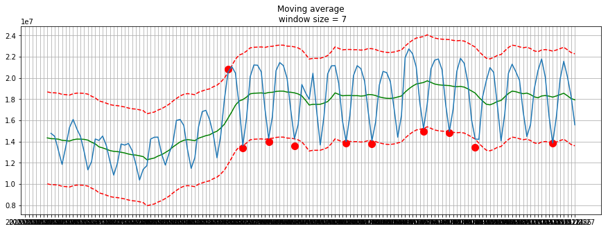

```python
dfn_es = RemoveOutliers(df_views['es'][:150], 7, plot_intervals=True, plot_anomalies=True)
```

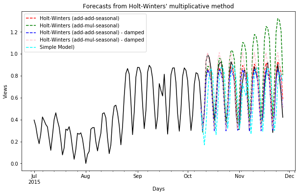

```
Forecasting views of wiki pages using Holt-Winters method with both additive and multiplicative seasonality.
```

```python
HoltWinters_Prediction_es = HoltWinters_Prediction_function(dfn_es)
```

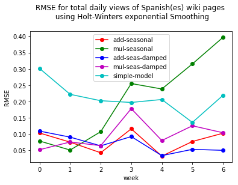

```python
HoltWinters_RMSE_es = HoltWinters_RMSE_Plot(dfn_es[100:150],HoltWinters_Prediction_es,"Spanish(es)")
```

```python
HoltWinters_RMSE_es
```

|  | add-seas | mul-seas | add-seas-dam | mul-seas-dam | simple-model |
| --- | --- | --- | --- | --- | --- |
| 0 | 0.103328 | 0.078806 | 0.109189 | 0.052095 | 0.301325 |
| 1 | 0.075303 | 0.051033 | 0.090692 | 0.075747 | 0.222053 |
| 2 | 0.042739 | 0.107342 | 0.063950 | 0.064448 | 0.202420 |
| 3 | 0.116139 | 0.255158 | 0.092410 | 0.178075 | 0.197138 |
| 4 | 0.032412 | 0.238384 | 0.033942 | 0.080285 | 0.206144 |
| 5 | 0.077316 | 0.315402 | 0.053228 | 0.125549 | 0.135825 |
| 6 | 0.102643 | 0.396733 | 0.050180 | 0.104202 | 0.218842 |

```python
HoltWinters_RMSE_es.mean()
```

```
add-seas        0.078554
mul-seas        0.206123
add-seas-dam    0.070513
mul-seas-dam    0.097200
simple-model    0.211964
dtype: float64
```

A few observations from the above plots and graphs:

- The errors from the "simple mode" and multiplicative seasonal are much higher than the Holt-Winter techniques.
- The errors in all the weeks are pretty low at around ~0.1.
- If we look at the average RMSE from different techniques, additive-seasonal and additive-seasonal-damped give the lowest errors.

Now we will repeat this exercise with Japanese wiki pages.

#### 4.3.1.c Japanese

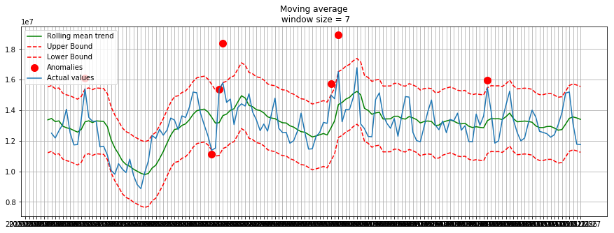

```python
dfn_ja = RemoveOutliers(df_views['ja'][:150], 7, plot_intervals=True, plot_anomalies=True)
```

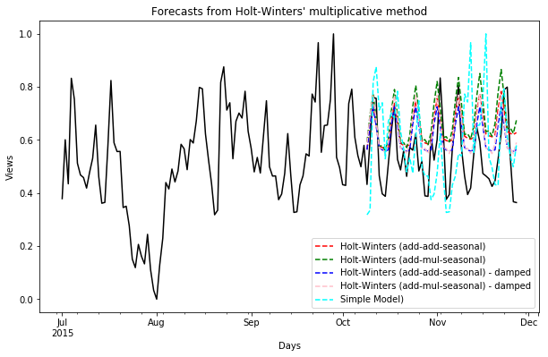

```
Forecasting views of wiki pages using Holt-Winters method with both additive and multiplicative seasonality.
```

```python
HoltWinters_Prediction_ja = HoltWinters_Prediction_function(dfn_ja)
```

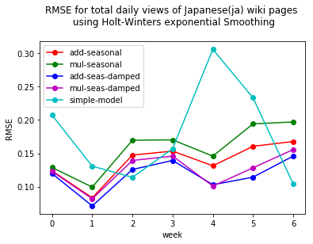

```python
HoltWinters_RMSE_ja = HoltWinters_RMSE_Plot(dfn_ja[100:150],HoltWinters_Prediction_ja,"Japanese(ja)")
```

```python
HoltWinters_RMSE_ja
```

|  | add-seas | mul-seas | add-seas-dam | mul-seas-dam | simple-model |
| --- | --- | --- | --- | --- | --- |
| 0 | 0.123816 | 0.128794 | 0.119669 | 0.123011 | 0.207249 |
| 1 | 0.083227 | 0.099330 | 0.071119 | 0.081754 | 0.130758 |
| 2 | 0.147342 | 0.169627 | 0.125754 | 0.139323 | 0.114049 |
| 3 | 0.153378 | 0.170225 | 0.139315 | 0.145833 | 0.156885 |
| 4 | 0.131261 | 0.145805 | 0.102914 | 0.100989 | 0.306052 |
| 5 | 0.160527 | 0.194234 | 0.114220 | 0.128266 | 0.233313 |
| 6 | 0.167793 | 0.197062 | 0.145877 | 0.155651 | 0.103978 |

```python
HoltWinters_RMSE_ja.mean()
```

```
add-seas        0.138192
mul-seas        0.157868
add-seas-dam    0.116981
mul-seas-dam    0.124975
simple-model    0.178898
dtype: float64
```

### 4.3.2. Predictions for daily views of individual pages

We randomly sample 100 wiki pages and organize them in order of the mean views. The idea is to make prediction for pages which have more number of views.

```python
dfs = df.sample(n=100, random_state=2)
dfs = dfs.drop(['Unnamed: 0','PageName','Access', 'Agent', 'Avg','Lang','Project'],axis = 1) #drop coulumns
dfs.set_index('Page', inplace=True)
dfs = dfs.T
dfs = dfs.reindex(dfs.mean().sort_values().index, axis=1) #ascending order of column mean
dfs.describe()
```

| Page | 恶魔少爷别吻我_zh.wikipedia.org_all-access_spider | User:Anasserrihani_commons.wikimedia.org_all-access_spider | User:Rxy_www.mediawiki.org_mobile-web_all-agents | Manual:Installation_guide/en-gb_www.mediawiki.org_mobile-web_all-agents | Boreczek,_Masovian_Voivodeship_en.wikipedia.org_all-access_all-agents | Gustavo_Gaviria_fr.wikipedia.org_all-access_spider | Extension:HTML5video_www.mediawiki.org_all-access_spider | Julia_Piaton_fr.wikipedia.org_all-access_spider | Special:MyLanguage/Manual:MediaWiki_feature_list_www.mediawiki.org_mobile-web_all-agents | Commons:Wiki_Loves_Monuments_2016_in_the_United_States/Washington_commons.wikimedia.org_desktop_all-agents | ... | 田口智治_ja.wikipedia.org_all-access_all-agents | Internet_Movie_Database_de.wikipedia.org_all-access_all-agents | Wikipedia_en_español_es.wikipedia.org_all-access_all-agents | Deepwater_Horizon_oil_spill_en.wikipedia.org_all-access_all-agents | 安倍晋三_ja.wikipedia.org_all-access_all-agents | William_Shakespeare_es.wikipedia.org_all-access_all-agents | Teenage_Mutant_Ninja_Turtles_en.wikipedia.org_mobile-web_all-agents | Pretty_Little_Liars_(TV_series)_en.wikipedia.org_mobile-web_all-agents | Inside_Out_(2015_film)_en.wikipedia.org_desktop_all-agents | 真田丸_(NHK大河ドラマ)_ja.wikipedia.org_all-access_all-agents |
| --- | --- | --- | --- | --- | --- | --- | --- | --- | --- | --- | --- | --- | --- | --- | --- | --- | --- | --- | --- | --- | --- |
| count | 550.0 | 550.000000 | 550.000000 | 550.000000 | 550.000000 | 550.000000 | 550.00000 | 550.000000 | 550.000000 | 550.000000 | ... | 5.500000e+02 | 550.000000 | 550.000000 | 550.000000 | 550.000000 | 550.000000 | 550.000000 | 550.000000 | 550.000000 | 550.000000 |
| mean | 0.0 | 0.198182 | 0.950909 | 1.841818 | 1.940000 | 2.274545 | 2.46000 | 4.529091 | 5.361818 | 5.365455 | ... | 2.911602e+03 | 3073.052727 | 3690.660000 | 4125.805455 | 4908.587273 | 5271.789091 | 5455.521818 | 5947.141818 | 6408.567273 | 10671.494545 |
| std | 0.0 | 0.574818 | 1.386688 | 2.564731 | 1.810222 | 13.903489 | 2.02382 | 11.670572 | 4.001138 | 23.521704 | ... | 5.497638e+04 | 621.716540 | 805.419498 | 4329.605611 | 3496.188241 | 8904.906486 | 2251.209723 | 6589.438204 | 4888.331882 | 12022.883738 |
| min | 0.0 | 0.000000 | 0.000000 | 0.000000 | 0.000000 | 0.000000 | 0.00000 | 0.000000 | 0.000000 | 0.000000 | ... | 1.800000e+01 | 1886.000000 | 1613.000000 | 853.000000 | 2288.000000 | 961.000000 | 2670.000000 | 469.000000 | 1744.000000 | 1199.000000 |
| 25% | 0.0 | 0.000000 | 0.000000 | 0.000000 | 1.000000 | 0.000000 | 1.00000 | 2.000000 | 2.000000 | 0.000000 | ... | 4.000000e+01 | 2626.750000 | 3129.500000 | 2023.500000 | 3272.500000 | 3133.500000 | 4116.500000 | 1105.750000 | 2573.000000 | 3644.750000 |
| 50% | 0.0 | 0.000000 | 0.000000 | 0.000000 | 2.000000 | 0.000000 | 2.00000 | 3.000000 | 5.500000 | 0.000000 | ... | 5.100000e+01 | 2982.000000 | 3685.500000 | 2710.500000 | 3974.500000 | 4197.500000 | 4962.500000 | 5478.000000 | 4440.500000 | 7185.500000 |
| 75% | 0.0 | 0.000000 | 1.000000 | 3.000000 | 3.000000 | 2.000000 | 3.00000 | 5.000000 | 8.000000 | 0.000000 | ... | 7.700000e+01 | 3352.250000 | 4232.000000 | 3593.250000 | 4875.000000 | 5490.500000 | 5928.250000 | 7599.750000 | 9197.750000 | 12422.500000 |
| max | 0.0 | 6.000000 | 8.000000 | 12.000000 | 11.000000 | 257.000000 | 22.00000 | 230.000000 | 21.000000 | 164.000000 | ... | 1.285359e+06 | 6310.000000 | 6980.000000 | 28310.000000 | 38900.000000 | 190156.000000 | 26949.000000 | 108782.000000 | 35882.000000 | 147732.000000 |

8 rows × 100 columns

Looking at the table, the pages with highest average views are: 真田丸 (ja), Inside Out (en) and Pretty Little Liars. Lets make predictions for all three:

#### 4.3.2.a 真田丸

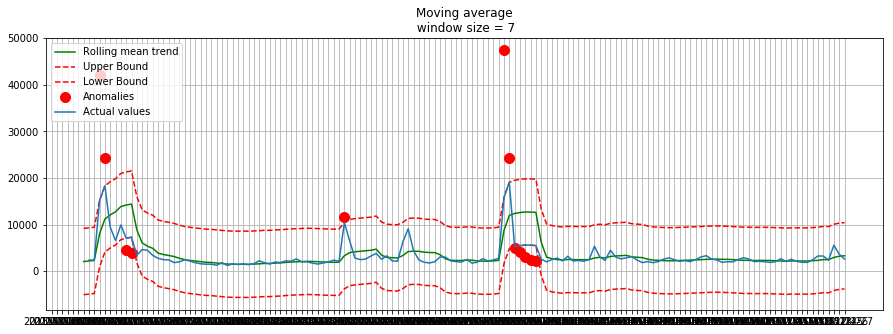

```python
dfsn_99 = RemoveOutliers(dfs.iloc[:150,99], 7, plot_intervals=True, plot_anomalies=True)
```

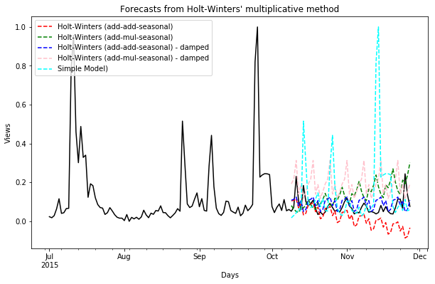

```
Forecasting views of wiki pages using Holt-Winters method with both additive and multiplicative seasonality.
```

```python
HoltWinters_Prediction_99 = HoltWinters_Prediction_function(dfsn_99)
```

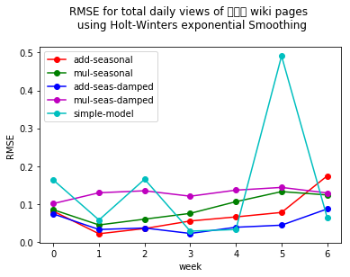

```python
HoltWinters_RMSE_99 = HoltWinters_RMSE_Plot(dfsn_99.iloc[100:150],HoltWinters_Prediction_99,"真田丸")
```

```python
HoltWinters_RMSE_99
```

|  | add-seas | mul-seas | add-seas-dam | mul-seas-dam | simple-model |
| --- | --- | --- | --- | --- | --- |
| 0 | 0.081214 | 0.085124 | 0.074064 | 0.101393 | 0.163545 |
| 1 | 0.021766 | 0.044998 | 0.032996 | 0.129925 | 0.058132 |
| 2 | 0.035527 | 0.060320 | 0.036946 | 0.135120 | 0.165655 |
| 3 | 0.055450 | 0.075568 | 0.022588 | 0.120803 | 0.028675 |
| 4 | 0.066213 | 0.106397 | 0.038926 | 0.136829 | 0.032948 |
| 5 | 0.078007 | 0.132983 | 0.044420 | 0.144017 | 0.490786 |
| 6 | 0.174392 | 0.124128 | 0.087182 | 0.129467 | 0.064224 |

```python
HoltWinters_RMSE_99.mean()
```

```
add-seas        0.073224
mul-seas        0.089931
add-seas-dam    0.048160
mul-seas-dam    0.128222
simple-model    0.143424
dtype: float64
```